# Boost Converter: DCM Small-Signal Model

1. Output voltage
2. $G_{d0}$
3. $\omega _p$

Verify the small signal model by applying a step change in duty cycle (change duty cycle from 0.5 to 0.51) and plot the response from transfer function and from simulation on the same graph.

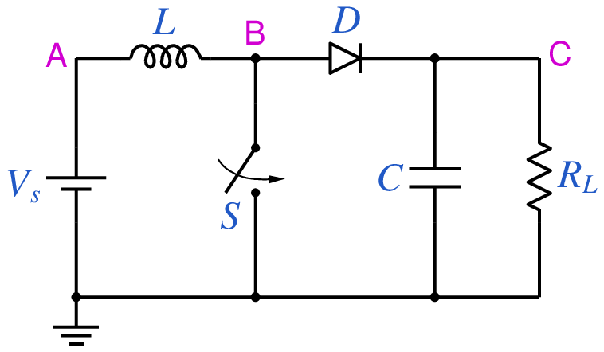

```python
from IPython.display import Image
Image(filename =r'boost_dcm_4_fig_1.png', width=320)
```

```python
# run this cell to view the circuit file.
%pycat boost_dcm_4_orig.in
```

We now replace the strings such as \$D1, \$D2, with the values of our choice by running the python script given below. It takes an existing circuit file `boost_dcm_4_orig.in` and produces a new circuit file `boost_dcm_4.in`, after replacing \$D1, \$D2, etc. with values of our choice. Note the use of the `set_rparm` statement in the solve block to equate the parameter `D` of the element named `clock1` by the value of the variable `y` of the element named `pwl`. `pwl` generates a step change which is coupled to `D` of `clock1` by the `set_rparm` statement.

```python
import gseim_calc as calc
s_D1 = '0.5'
s_D2 = '0.51'
s_t1 = '25e-3'
s_t2 = '25.001e-3'

l = [
  ('$D1', s_D1),
  ('$D2', s_D2),
  ('$t1', s_t1),
  ('$t2', s_t2)
]
calc.replace_strings_1("boost_dcm_4_orig.in", "boost_dcm_4.in", l)
print('boost_dcm_4.in is ready for execution')
```

```
boost_dcm_4.in is ready for execution
```

**Execute the following cell to run GSEIM on boost_dcm_4.in.**

```python
import os
import dos_unix
# uncomment for windows:
#dos_unix.d2u("boost_dcm_4.in")
os.system('run_gseim boost_dcm_4.in')
```

```
Circuit: filename = boost_dcm_4.in
main: calling solve_trns
Transient simulation starts...
i=0
i=10000
i=20000
i=30000
i=40000
i=50000
i=60000
i=70000
i=80000
GSEIM: Program completed.
```

```
0
```

The circuit file (`boost_dcm_4.in`) is created in the same directory as that used for launching Jupyter notebook. The last step (i.e., running `GSEIM` on `boost_dcm_4.in`) creates a data file `boost_dcm_4.dat` in the same directory. We can now use the python code below to plot the output voltage versus time to ensure that the circuit is in a steady state before the step in $D$. If it is not, it would not make sense to compare the simulation results with the results (to be obtained in a later cell) of the boost converter small-signal model.

```
filename: boost_dcm_4.dat
```

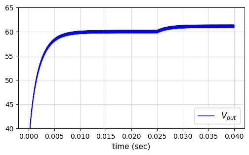

```python
import numpy as np
import matplotlib.pyplot as plt
import gseim_calc as calc
from setsize import set_size

slv = calc.slv("boost_dcm_4.in")

i_slv = 0
i_out = 0
filename = slv.l_filename_all[i_slv][i_out]
print('filename:', filename)
u = np.loadtxt(filename)
t = u[:, 0]

IL = slv.get_array_double(i_slv,i_out,"IL",u)
IS = slv.get_array_double(i_slv,i_out,"IS",u)
ID = slv.get_array_double(i_slv,i_out,"ID",u)
IC = slv.get_array_double(i_slv,i_out,"IC",u)
v_in = slv.get_array_double(i_slv,i_out,"v_in",u)
v_out = slv.get_array_double(i_slv,i_out,"v_out",u)
clock = slv.get_array_double(i_slv,i_out,"clock",u)

color1='green'
color2='crimson'
color3='goldenrod'
color4='blue'

fig, ax = plt.subplots()
plt.subplots_adjust(wspace=0, hspace=0.0)

set_size(4, 2.5, ax)

plt.grid(color='#CCCCCC', linestyle='solid', linewidth=0.5)
ax.set_ylim(bottom=40, top=65)

ax.plot(t, v_out, color=color4, linewidth=1.0, label="$V_{out}$")

plt.xlabel('time (sec)', fontsize=11)

ax.legend(loc = 'lower right',frameon = True, fontsize = 10, title = None,
   markerfirst = True, markerscale = 1.0, labelspacing = 0.5, columnspacing = 2.0,
   prop = {'size' : 12},)

plt.tight_layout()
plt.show()
```

```
Vin: 10.0
L: 1e-05
C: 0.0001
R: 48.0
f_hz: 20000.0
t_step: 0.025
D1: 0.5
D2: 0.51
t_end: 0.04
Vo:  6.0000E+01
Gd0:  1.0909E+02
w_p:  4.5833E+02
filename: boost_dcm_4.dat
```

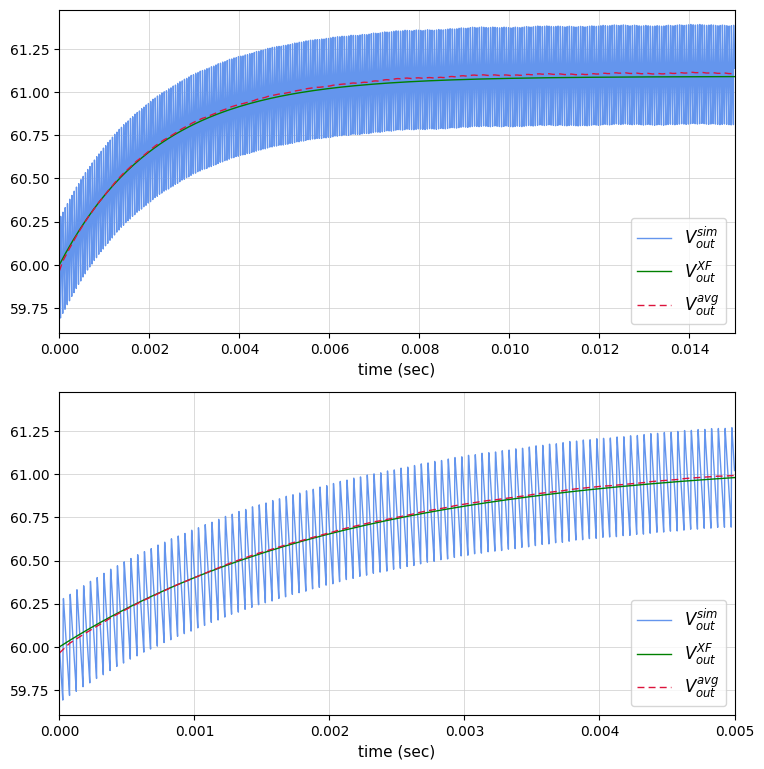

```python
import control as ct
import numpy as np
import matplotlib.pyplot as plt
import gseim_calc as calc
from setsize import set_size

# get values of Vin, D, etc from the circuit file:
fin = open("boost_dcm_4.in", "r")
for line in fin:
    if 'name=VS' in line:
        for s in line.split():
            if s.startswith('vdc='):
                Vin = float(s.split('=')[1])
                print('Vin:', Vin)
    if 'name=clock1' in line:
        for s in line.split():
            if s.startswith('f_hz='):
                f_hz = float(s.split('=')[1])
                print('f_hz:', f_hz)
    if 'name=pwl' in line:
        for s in line.split():
            if s.startswith('v1='):
                D1 = float(s.split('=')[1])
                print('D1:', D1)
            if s.startswith('v2='):
                D2 = float(s.split('=')[1])
                print('D2:', D2)
            if s.startswith('t1='):
                # t_step: time when D changes from D1 to D2
                t_step = float(s.split('=')[1])
                print('t_step:', t_step)
    if 'name=L' in line:
        for s in line.split():
            if s.startswith('l='):
                L = float(s.split('=')[1])
                print('L:', L)
    if 'name=C' in line:
        for s in line.split():
            if s.startswith('c='):
                C = float(s.split('=')[1])
                print('C:', C)
    if 'name=R' in line:
        for s in line.split():
            if s.startswith('r='):
                R = float(s.split('=')[1])
                print('R:', R)
    if 't_end=' in line:
        for s in line.split():
            if s.startswith('t_end='):
                t_end = float(s.split('=')[1])
                print('t_end:', t_end)

fin.close()

T = 1.0/f_hz

# Compute transfer function parameters:

Vo = Vin*(1 + np.sqrt(1 + 4*D1*D1/(2*L/R/T)))/2
M = Vo/Vin
Gd0 = 2*Vo*(M-1)/(2*M-1)/D1
w_p = (2*M-1)/((M-1)*R*C)

print('Vo:', "%11.4E"%Vo)
print('Gd0:', "%11.4E"%Gd0)
print('w_p:', "%11.4E"%w_p)

# construct transfer function of the boost converter small-signal model:
num = np.array([Gd0])
den = np.array([(1.0/w_p),1.0])
H1 = ct.tf(num, den)

# Compute step response, treating t_step as t=0.
t_end_1 = t_end - t_step
t_vec = np.linspace(0,t_end_1,200)

# xf stands for transfer function
t_xf, y_xf1 = ct.step_response(H1,t_vec)
# scale y_xf1, taking into account initial and final values of Vout
y_xf = Vo + y_xf1*(D2-D1)
color1='green'
color2='crimson'
color3='cornflowerblue'
color4='blue'

fig, ax = plt.subplots(2, sharex=False)
plt.subplots_adjust(wspace=0, hspace=0.0)

set_size(6, 6, ax[0])

# plot Vout obtained by simulation:

slv = calc.slv("boost_dcm_4.in")

i_slv = 0
i_out = 0
filename = slv.l_filename_all[i_slv][i_out]
print('filename:', filename)
u = np.loadtxt(filename)

IL = slv.get_array_double(i_slv,i_out,"IL",u)
IS = slv.get_array_double(i_slv,i_out,"IS",u)
ID = slv.get_array_double(i_slv,i_out,"ID",u)
IC = slv.get_array_double(i_slv,i_out,"IC",u)
v_in = slv.get_array_double(i_slv,i_out,"v_in",u)
v_out = slv.get_array_double(i_slv,i_out,"v_out",u)
clock = slv.get_array_double(i_slv,i_out,"clock",u)

t_sim = u[:, 0] - t_step

l_t_sim = []
l_vout_sim = []

for i, t in enumerate(t_sim):
    if t >= 0.0:
        l_t_sim.append(t)
        l_vout_sim.append(v_out[i])

l1 = calc.avg_rms_1(np.array(l_t_sim), np.array(l_vout_sim), T)

ax[0].grid(color='#CCCCCC', linestyle='solid', linewidth=0.5)
ax[0].set_xlim(left=0.0, right=t_end_1)
ax[0].set_xlabel('time (sec)', fontsize=11)
ax[0].plot(l_t_sim, l_vout_sim, color=color3, linewidth=1.0, label="$V_{out}^{sim}$")

# plot Vout obtained from transfer function:
ax[0].plot(t_xf, y_xf, color=color1, linewidth=1.0, label="$V_{out}^{XF}$")

# plot average value of Vout as obtained by simulation:
ax[0].plot(l1[0], l1[1], color=color2, linewidth=1.0, linestyle='--', dashes=(5,3), label="$V_{out}^{avg}$")

ax[0].legend(loc = 'lower right',frameon = True, fontsize = 10, title = None,
   markerfirst = True, markerscale = 1.0, labelspacing = 0.5, columnspacing = 2.0,
   prop = {'size' : 12},)

ax[1].grid(color='#CCCCCC', linestyle='solid', linewidth=0.5)
ax[1].set_xlim(left=0.0, right=0.005)
ax[1].set_xlabel('time (sec)', fontsize=11)
ax[1].plot(l_t_sim, l_vout_sim, color=color3, linewidth=1.0, label="$V_{out}^{sim}$")
ax[1].plot(t_xf, y_xf, color=color1, linewidth=1.0, label="$V_{out}^{XF}$")
ax[1].plot(l1[0], l1[1], color=color2, linewidth=1.0, linestyle='--', dashes=(5,3), label="$V_{out}^{avg}$")

ax[1].legend(loc = 'lower right',frameon = True, fontsize = 10, title = None,
   markerfirst = True, markerscale = 1.0, labelspacing = 0.5, columnspacing = 2.0,
   prop = {'size' : 12},)

plt.tight_layout()
plt.show()
```

This notebook was contributed by **Prof. Nakul Narayanan K**, Govt. Engineering College, Thrissur. He may be contacted at nakul@gectcr.ac.in.